# STA5073Z Assignment 2: Writer identification from handwritten digits

Authors

Karabo Matje

Innocentia Nemukula

Ludwick Hlongwane

# 1 Introduction

Handwriting is personal, and examiners have long used it to judge who wrote a document. Reviews of writer identification describe how the field moved from hand-made features to machine learning and, more recently, deep learning (Rehman et al., 2019). Convolutional neural networks (CNNs) learn features straight from the pixels and have been used to identify writers from images of their handwriting (Gu et al., 2018; He & Schomaker, 2019). A second route treats the problem as similarity learning: instead of naming the writer, a Siamese network judges whether two samples came from the same hand, so it can be applied to writers it has not seen (Chicco, 2021). This report builds both models on simulated images of the digits 0 to 4 written by 20 writers. We explore the data (Task 1), fit a CNN that identifies the writer (Task 2), fit a Siamese network that verifies whether two images share a writer (Task 3), explain how the data were split and how leakage was avoided (Task 4), tune the CNN (Task 5) and compare the two models (Task 6).

# 2 Data exploration

## 2.1 Data Overview

The data consisted of 25,000 greyscale images of 28 x 28 pixels, showing the digits 0 to 4. Each of the 20 writers wrote each digit 50 times (replicate) in each of the 5 sessions, giving a total of 1,250 images per writer. The original pixel values [0,255], were scaled to [0, 1] before fitting the neural network models, because inputs on a small common scale make gradient-based training more stable (Chollet et al., 2022; Goodfellow et al., 2016). The metadata contains the image ID, writer ID, digit, session number and replicate number. To explore the sources of variability in the data, four analyses were carried out including variation between writers, variation across sessions for a subset of writers, variation within sessions (across replicates) for a subset of writers, and a quantitative comparison of the three using pixel distances.

## 2.2 Variation between writers

To examine variation between writers, each digit was plotted for all 20 writers, with session and replicate fixed at 1. This produced five plots, one per digit. Writer-identification methods rely on the fact that people differ in features such as size, shape and slant (Rehman et al., 2019), so we looked for these features. Figure 1 shows clear differences in handwriting style between the 20 writers.

```r
plot_writers(0)
plot_writers(1)
```

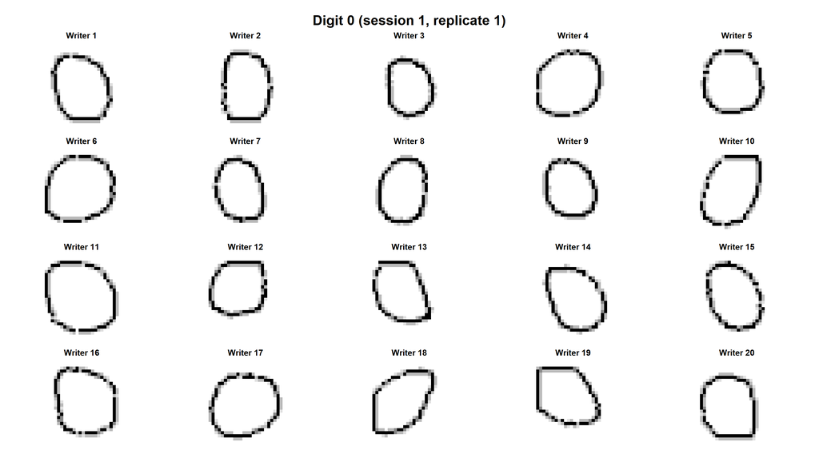

(a) Digit 0

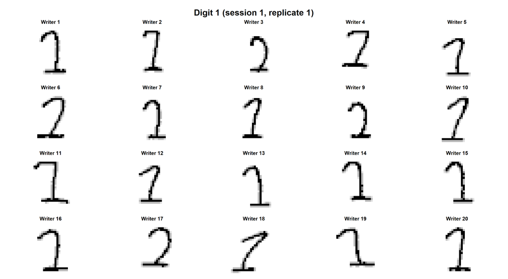

(b) Digit 1

Figure 1: Digits 0 and 1 for all 20 writers, with session 1 and replicate 1 fixed.

Variation in shape is most clearly observed in digits 0 and 1 (Figure 1). For example, although all the 1s have a base, some have a hook at the top (writers 1, 7 and 14), while others have a curved body that resembles the digit 2 (writers 3, 9 and 17). For digit 0, shapes vary from round to oval, and some writers (10, 12, 13 and 19) draw squarer shapes with a flat top. The remaining digits follow a more consistent style, with the primary differences being slant and size. Size also varies whereby some writers (3 and 9) write small and compact digits, while others fill the space with large digits. Slant varies from upright to a rightward slant (writers 18 and 10), while writer 19 slants to the left. These differences in size, shape and slant are features that the models could learn. The plots for digits 2, 3 and 4 are in Figure 15 (Appendix A).

## 2.3 Variation across sessions

To assess whether a person’s handwriting changes between sessions, 10 writers were randomly sampled and each digit was plotted across the 5 sessions, with the replicate fixed at 1. The plots for digits 2, 3 and 4 are in Figure 16 (Appendix A).

```r
plot_sessions_sample(1)
plot_sessions_sample(0)
```

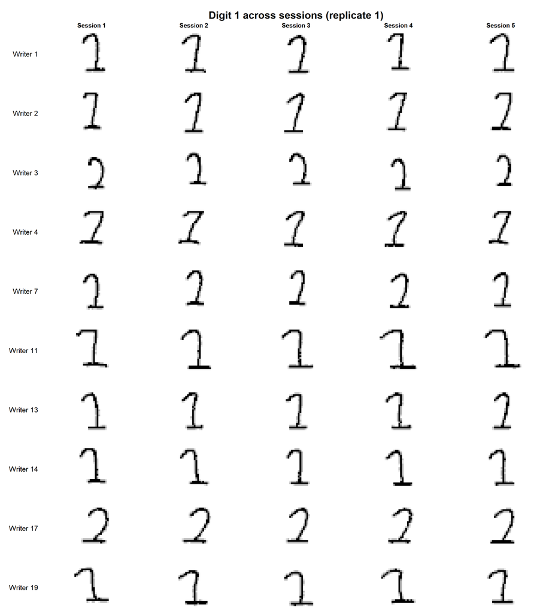

(a) Digit 1

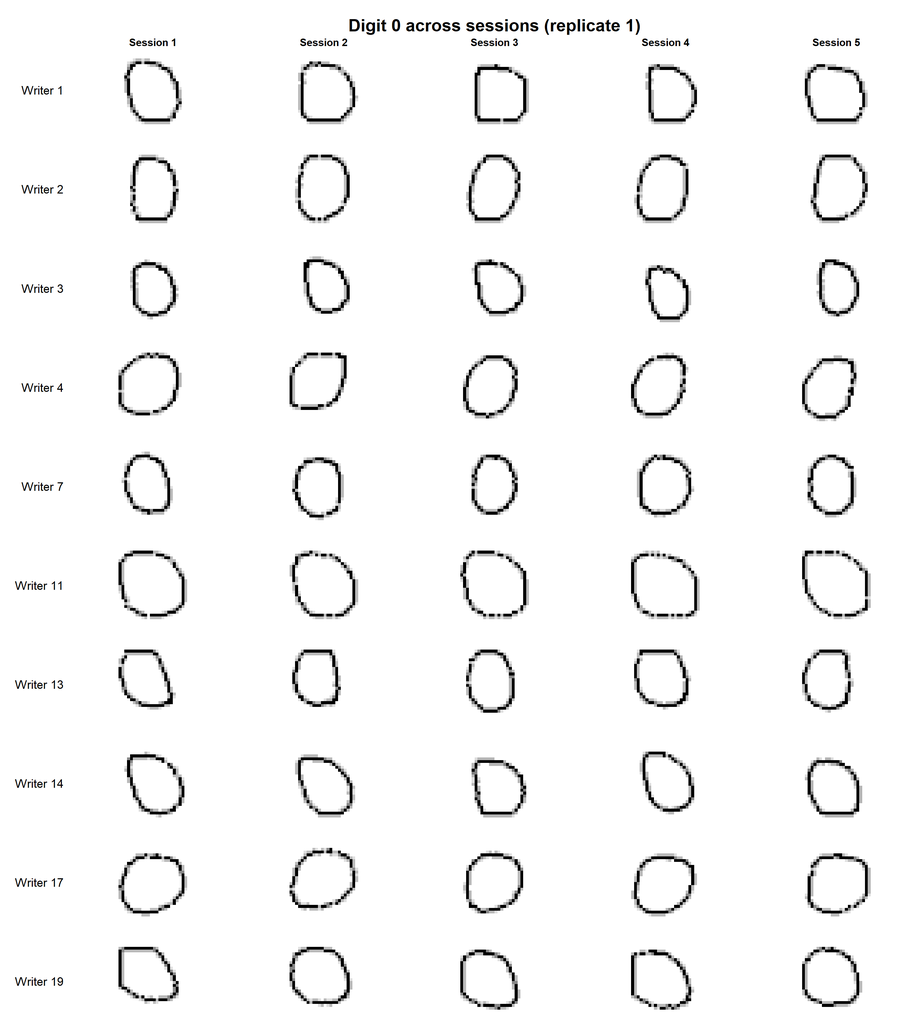

(b) Digit 0

Figure 2: Digits 1 and 0 for ten randomly sampled writers (seed 1), with replicate 1 fixed. Rows are writers and columns are sessions 1 to 5.

There are visible changes in style between sessions, and these are more noticeable for some writers than for others. Although some changes are noticeable, some writers remained consistent in certain characteristics. For example, writer 3 wrote small digits in all sessions and, for digit 1, kept their signature hook in every session, as writer 17 did. Other writers changed their characteristic style, for example, writer 19 slanted the digits slightly to the left in the first session, but the digits became more upright as the sessions progressed. Writer 1’s 1s also changed between sessions because some have hooks and the lengths of the strokes differ. This indicates that a writer’s handwriting may change between sessions. Although some of these changes are minor, they alter a writer’s characteristic style from session 1, so the models may identify some writers less accurately in a new session.

## 2.4 Variation across replicates

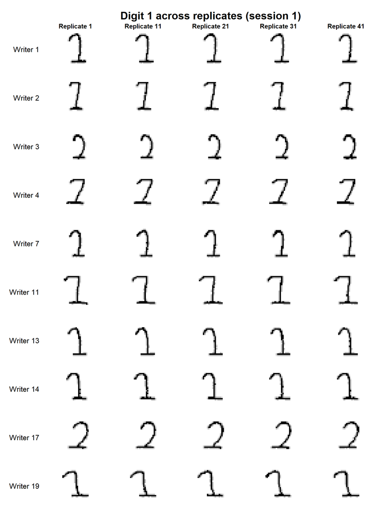

Figure 3: Digit 1 for the same ten writers as in the sessions figure, with session 1 fixed and replicates 1, 11, 21, 31 and 41. Rows are writers and columns are replicates.

```r
plot_replicates(1)
```

To assess whether handwriting style drifted across replicates within a session, the same 10 writers were used, with replicates 1, 11, 21, 31 and 41 plotted for session 1 (fixed). The digits were near-identical across the replicates, with little to no change in style. This indicates that a writer’s handwriting within one session is usually the same. The plots for digits 0, 2, 3 and 4 are in Figure 17 (Appendix A).

## 2.5 Quantifying the variation

To quantify the variation between writers, across sessions and within sessions, the Euclidean distance between two images was computed over all 784 pixels. For a sample of 1,000 draws, the function picked a writer, a digit, two sessions and two replicates and formed three comparisons with the digit matched within a session (comparing replicates), across sessions (the same writer) and between writers. The three distances were compared with a Friedman test, followed by paired Wilcoxon signed-rank tests with Holm’s adjustment for the three comparisons. We also report the paired effect size d<sub>z</sub>, the mean of the paired differences divided by their standard deviation (Goulet-Pelletier & Cousineau, 2018). Intervals are percentile bootstrap intervals from 2000 resamples of the draws (Efron & Hastie, 2016).

Two images of the same digit by the same writer in the same session were near identical (mean distance = 2.72, SD = 0.50), which indicates that the 50 replicates are near copies of one another. The across-session distance for the same writer had a mean of 7.15 and SD = 1.63. The highest variation was recorded between different writers (mean distance = 8.59, SD = 1.14) (Table 1, Figure 4). The three distances differ clearly in the matched draws (Friedman chi-squared = 1652.9 on 2 df, p < 1e-16; Kendall’s W = 0.83), and all three Holm-adjusted pairwise tests give p < 1e-16 (Table 2).

```r
knitr::kable(desc, digits = 2, row.names = FALSE, align = "lccccccc",
             col.names = c("Comparison", "Draws", "Mean", "SD", "Median", "IQR",
                           "95% CI low", "95% CI high"))
```

Table 1: Pixel distance between two images of the same digit, by comparison type (1,000 draws), with 95% bootstrap intervals for the mean.

| Comparison | Draws | Mean | SD | Median | IQR | 95% CI low | 95% CI high |
| --- | --- | --- | --- | --- | --- | --- | --- |
| Within-session | 1000 | 2.72 | 0.50 | 2.76 | 0.68 | 2.69 | 2.75 |
| Across-session | 1000 | 7.15 | 1.63 | 7.19 | 2.32 | 7.05 | 7.24 |
| Between-writer | 1000 | 8.59 | 1.14 | 8.68 | 1.55 | 8.52 | 8.66 |

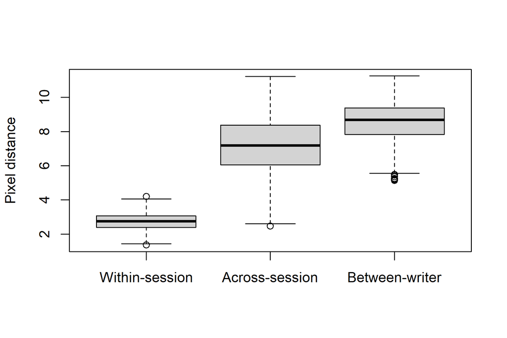

Figure 4: Distribution of pixel distances by comparison type.

```r
boxplot(M, names = c("Within-session", "Across-session", "Between-writer"),
        ylab = "Pixel distance")
```

With 1,000 draws almost any difference would be significant, so the effect sizes are more informative than the p-values. The across-session minus within-session gap is 4.43 (95% CI 4.33 to 4.53; d<sub>z</sub> = 2.72), whereas the between-writer minus across-session gap is only 1.44 (95% CI 1.33 to 1.56; d<sub>z</sub> = 0.77). In practical terms, a change of session moves a writer’s digit about 75% of the way to where a different writer’s digit sits ((7.15 − 2.72) / (8.59 − 2.72)). A writer is therefore only partly recognisable from the pixels of a single image, and any model has to cope with the same person looking different from one session to the next.

```r
tab_tests <- data.frame(
  Comparison = pw$Comparison,
  `Mean difference (95% CI)` = sprintf("%.2f (%.2f to %.2f)", pw$Mean_diff, pw$CI_low, pw$CI_high),
  dz = round(pw$d_z, 2),
  `Holm-adjusted p` = ifelse(pw$p_Holm < 1e-16, "< 1e-16", signif(pw$p_Holm, 2)),
  check.names = FALSE)
knitr::kable(tab_tests, align = "lccc")
```

Table 2: Paired differences between comparison types: mean difference with 95% bootstrap interval, paired effect size dz, and Holm-adjusted Wilcoxon signed-rank p-values.

| Comparison | Mean difference (95% CI) | dz | Holm-adjusted p |
| --- | --- | --- | --- |
| Across minus Within | 4.43 (4.33 to 4.53) | 2.72 | < 1e-16 |
| Between minus Within | 5.87 (5.80 to 5.94) | 5.27 | < 1e-16 |
| Between minus Across | 1.44 (1.33 to 1.56) | 0.77 | < 1e-16 |

```r
tab_digit <- data.frame(
  Digit = ratio_by_digit$Digit,
  Draws = ratio_by_digit$n,
  `Within-session` = round(ratio_by_digit$Within, 2),
  `Across-session` = round(ratio_by_digit$Across, 2),
  `Between-writer` = round(ratio_by_digit$Between, 2),
  `Across / within (95% CI)` = sprintf("%.2f (%.2f to %.2f)", ratio_by_digit$Ratio,
                                       ratio_by_digit$CI_low, ratio_by_digit$CI_high),
  check.names = FALSE)
knitr::kable(tab_digit, align = "cccccc")
```

Table 3: Mean pixel distance by digit and comparison type, and the ratio of across-session to within-session distance with a 95% bootstrap interval.

| Digit | Draws | Within-session | Across-session | Between-writer | Across / within (95% CI) |
| --- | --- | --- | --- | --- | --- |
| 0 | 201 | 2.94 | 7.53 | 9.24 | 2.56 (2.48 to 2.64) |
| 1 | 184 | 2.01 | 6.83 | 8.00 | 3.40 (3.27 to 3.53) |
| 2 | 200 | 2.93 | 7.45 | 8.66 | 2.54 (2.46 to 2.63) |
| 3 | 214 | 2.75 | 7.03 | 8.61 | 2.56 (2.46 to 2.66) |
| 4 | 201 | 2.91 | 6.88 | 8.39 | 2.36 (2.29 to 2.43) |

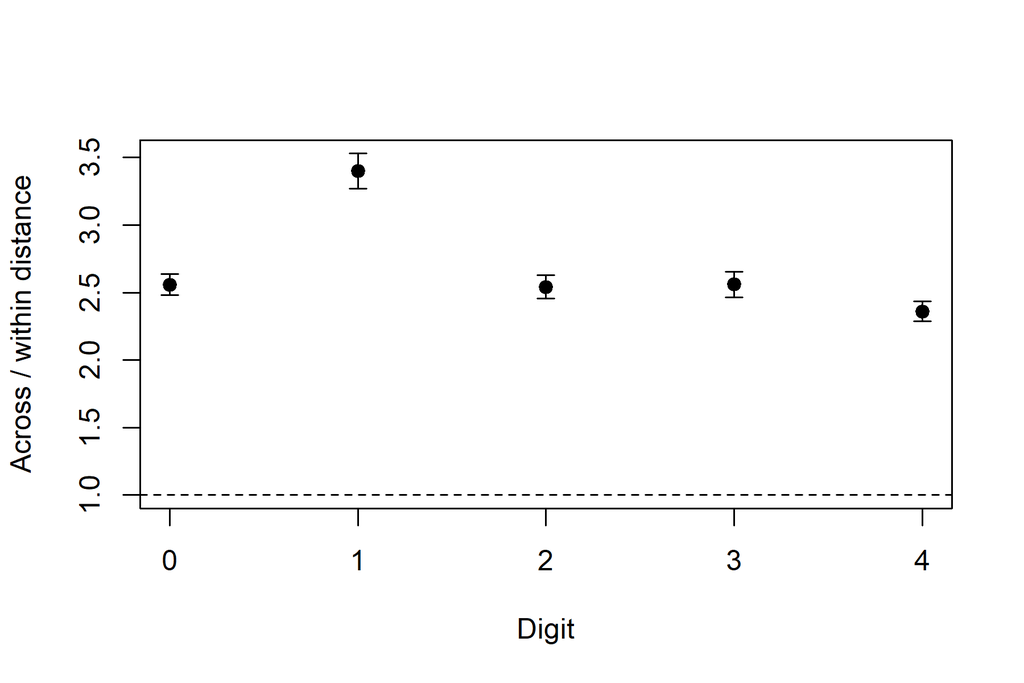

Figure 5: Ratio of across-session to within-session distance by digit, with 95% bootstrap intervals. The dashed line marks a ratio of 1.

```r
plot(ratio_by_digit$Digit, ratio_by_digit$Ratio, pch = 19, xaxt = "n",
     xlab = "Digit", ylab = "Across / within distance",
     ylim = range(c(1, ratio_by_digit$CI_low, ratio_by_digit$CI_high)))
axis(1, at = 0:4)
arrows(ratio_by_digit$Digit, ratio_by_digit$CI_low,
       ratio_by_digit$Digit, ratio_by_digit$CI_high,
       angle = 90, code = 3, length = 0.05)
abline(h = 1, lty = 2)
```

This has a consequence for how the data are split in the next tasks. A random split would put near-copies of the same image in both the training and the test set, so it would measure memory more than generalisation.

# 3 Convolutional Neural Network (CNN)

Task 2 treats writer identification as a 20-class classification problem: the input is an image and the output is the writer’s ID. All 20 writers appear in the training data, so this is identification of known writers, not verification of unknown ones.

**Uncertainty.** The 50 replicates within a writer, digit and session are near copies, so images are not independent and a binomial interval treats the test set as holding more information than it does. We report the exact Clopper-Pearson interval for reference (Agresti, 2019), but base our uncertainty on a cluster bootstrap: whole writer-digit groups (100 in the test session, 20 per digit) are resampled with replacement and the accuracy is recomputed 2000 times, which keeps the dependence inside each group (Efron & Hastie, 2016; Saravanan et al., 2020). Differences between digits are tested with a Friedman test, using each writer’s accuracy on each digit as the unit and the writers as blocks.

```r
# Free memory
if (exists("x_flat")) rm(x_flat)
invisible(gc())
seed_all(1)

x <- data$images / 255
y_person <- data$metadata$person_id - 1L
data$images <- NULL   # the raw images are not needed again
invisible(gc())

# Splitting data by session. Session 1-3 for training, session 4 for validation and session 5 for testing

# Picking rows by session
meta <- data$metadata # this is the table with one row per image

train_rows <- which(meta$session %in% 1:3) # row numbers of session 1-3

val_rows <- which(meta$session == 4)
test_rows <- which(meta$session == 5)

# images and labels
x_train <- x[train_rows, , , , drop = FALSE]
y_train <- y_person[train_rows]

x_val <- x[val_rows, , , , drop = FALSE]
y_val <- y_person[val_rows]

x_test <- x[test_rows, , , , drop = FALSE]
y_test <- y_person[test_rows]
```

**Split.** We split by session: sessions 1 to 3 for training (15 000 images), session 4 for validation and session 5 for testing (5 000 images each). This asks whether a model trained on a person’s earlier writing recognises them in a later session, and it stops near-identical replicates (Section 2) from straddling the training and test sets. Random splitting of records that share a source is known to give optimistic results: random cross-validation on structured data underestimates predictive error because the dependence between records is ignored (Roberts et al., 2017), and Saeb et al. (2017) make the same case for subject-wise versus record-wise validation. Leakage between training and test data is a wider cause of over-optimistic results in machine-learning studies (Kapoor & Narayanan, 2023). As a check, we also trained the same model on a random split (15 000 images for training, 5 000 for validation).

```r
# CNN Model building
seed_all(1)   # fixed start weights, dropout masks and batch order for the baseline CNN
model <- keras_model_sequential(input_shape = c(28, 28, 1)) |>
  layer_conv_2d(filters = 32, kernel_size = 3, activation = "relu") |> #keeps positive signals only
  layer_max_pooling_2d(pool_size = 2) |>       #shrinks the image by half
  layer_conv_2d(filters = 64, kernel_size = 3, activation = "relu") |>
  layer_max_pooling_2d(pool_size = 2) |>
  layer_flatten() |>
  layer_dense(units = 64, activation = "relu") |>
  layer_dropout(rate = 0.3) |>
  layer_dense(units = 20, activation = "softmax")

# Compiling and training
model |> compile(
  loss = "sparse_categorical_crossentropy",
  optimizer = "adam",
  metrics = "accuracy"
)

history <- model |> fit(
  x_train, y_train,
  epochs = 10,
  batch_size = 128,
  validation_data = list(x_val, y_val),
  verbose = 2   # one line per epoch keeps the rendered report tidy
)
```

```r
# Checking for leakage using random split
set.seed(123)
idx <- sample(nrow(x))
rand_train <- idx[1:15000]
rand_val   <- idx[15001:20000]

x_tr_rand <- x[rand_train, , , , drop = FALSE]
y_tr_rand <- y_person[rand_train]
x_va_rand <- x[rand_val, , , , drop = FALSE]
y_va_rand <- y_person[rand_val]

seed_all(1)   # same seed as the baseline CNN, so the two models differ only in the split
model_rand <- keras_model_sequential(input_shape = c(28, 28, 1)) |>
  layer_conv_2d(filters = 32, kernel_size = 3, activation = "relu") |>
  layer_max_pooling_2d(pool_size = 2) |>
  layer_conv_2d(filters = 64, kernel_size = 3, activation = "relu") |>
  layer_max_pooling_2d(pool_size = 2) |>
  layer_flatten() |>
  layer_dense(units = 64, activation = "relu") |>
  layer_dropout(rate = 0.3) |>
  layer_dense(units = 20, activation = "softmax")

model_rand |> compile(
  loss = "sparse_categorical_crossentropy",
  optimizer = "adam",
  metrics = "accuracy"
)

# The objects defined above are x_tr_rand / y_tr_rand / x_va_rand / y_va_rand.
history_rand <- model_rand |> fit(
  x_tr_rand, y_tr_rand,
  epochs = 10,
  batch_size = 128,
  validation_data = list(x_va_rand, y_va_rand),
  verbose = 2
)

# The random-split copies of the images are no longer needed
rm(x_tr_rand, x_va_rand); invisible(gc())
```

**Model.** The CNN has two convolution and max-pooling blocks (32 and then 64 filters of size 3 × 3), which learn local stroke patterns and then combine them (Goodfellow et al., 2016; Gu et al., 2018). These are followed by rectified linear activations, a flatten layer, a dense layer of 64 units with 30% dropout (which randomly switches off units during training to reduce overfitting) and a softmax output of 20 units (Goodfellow et al., 2016). We trained with sparse categorical cross-entropy and the Adam optimiser for 10 epochs with batches of 128 (Chollet et al., 2022; Goodfellow et al., 2016).

```r
# Accuracy by digit
pred  <- model |> predict(x_val, verbose = 0)
pred_class <- max.col(pred) - 1L
meta_val  <- meta[val_rows, ]

acc_by_digit <- tapply(pred_class == y_val, meta_val$digit, mean)
acc_by_digit

# Evaluating the model
# test accuracy
model |> evaluate(x_test, y_test, verbose = 0)

# Accuracy by digit on test set
pred_test <- model |> predict(x_test, verbose = 0)
pred_class_test <- max.col(pred_test) - 1L
meta_test <- meta[test_rows, ]

acc_by_digit_test <- tapply(pred_class_test == y_test, meta_test$digit, mean)
acc_by_digit_test

# Results in a table
results_table <- data.frame(
  Digit = 0:4,
  Validation = round(100 * as.numeric(acc_by_digit), 1),
  Test = round(100 * as.numeric(acc_by_digit_test), 1)
)
```

```r
knitr::kable(results_table,
             col.names = c("Digit", "Validation accuracy (%)", "Test accuracy (%)"))
```

Table 4: Accuracy by digit on the validation (session 4) and test (session 5) sets.

| Digit | Validation accuracy (%) | Test accuracy (%) |
| --- | --- | --- |
| 0 | 46.4 | 57.8 |
| 1 | 63.6 | 57.1 |
| 2 | 46.4 | 51.1 |
| 3 | 66.3 | 67.0 |
| 4 | 50.0 | 56.3 |

**What the measures capture.** Accuracy is the proportion of images assigned to the right writer. Chance is 1/20 = 5%, because the 20 writers are equally represented. The confusion matrix shows which writers are mistaken for which, that is, whose handwriting looks alike to the model. Accuracy by digit asks how much writer information a single digit carries.

**Performance by digit.**

Table 4 shows the validation (session 4) and test (session 5) accuracy for each digit, using 1 000 images per digit in each session. On the test set the highest accuracy (67.0%) was for digit 3 and the lowest (51.1%) was for digit 2, a difference of 15.9 percentage points. Every digit is far above the 5% expected by chance when identifying among 20 writers, so each digit contains information about who wrote it.

On the validation set the highest accuracy (66.3%) was for digit 3 and the lowest (46.4%) was for digit 0. Between the two sets, accuracy for the digits changed by 0.7 to 11.4 percentage points, with the largest change for digit 0. The two highest digits differed between the sets (test: 0 and 3; validation: 1 and 3). The three lowest digits on the test set (2, 4 and 1) lie within 6.0 percentage points of each other, so their order is not reliable. In this run all digits carry writer information above chance. Digit 3 had the highest test accuracy, although the differences between digits are not statistically reliable (see below).

## 3.1 Results

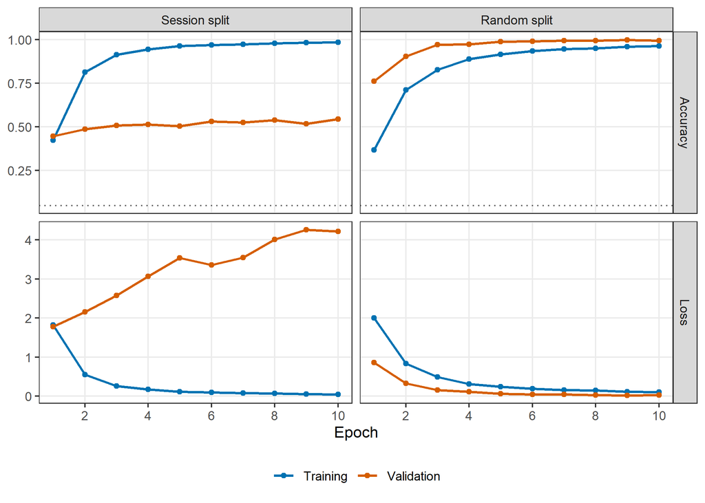

Figure 6: Training and validation accuracy and loss by epoch for the session split and the random split. The dotted line is the chance accuracy of 5%. Training metrics are running averages over each epoch with dropout active.

```r
hist_df <- function(h, label) {
  m <- h$metrics
  data.frame(epoch = rep(seq_along(m$loss), 2), split = label,
             set = rep(c("Training", "Validation"), each = length(m$loss)),
             accuracy = c(m$accuracy, m$val_accuracy), loss = c(m$loss, m$val_loss))
}
curves <- rbind(hist_df(history, "Session split"), hist_df(history_rand, "Random split"))
curves$split <- factor(curves$split, levels = c("Session split", "Random split"))
curves_long <- rbind(
  data.frame(curves[c("epoch", "split", "set")], metric = "Accuracy", value = curves$accuracy),
  data.frame(curves[c("epoch", "split", "set")], metric = "Loss", value = curves$loss))
ggplot(curves_long, aes(epoch, value, colour = set)) +
  geom_hline(data = data.frame(metric = "Accuracy", y = 0.05), aes(yintercept = y), linetype = 3, colour = "grey40") +
  geom_line(linewidth = .8) + geom_point(size = 1.5) +
  facet_grid(metric ~ split, scales = "free_y") +
  scale_colour_manual(values = c(Training = okabe[["blue"]], Validation = okabe[["red"]]), name = NULL) +
  scale_x_continuous(breaks = seq(2, 10, 2)) +
  labs(x = "Epoch", y = NULL)
```

```r
knitr::kable(acc_summary, digits = 3, row.names = FALSE,
             col.names = c("Split", "Evaluated on", "n", "Accuracy", "CP low", "CP high", "Boot low", "Boot high"))
```

Table 5: Writer-identification accuracy under the two splits. For the test set: exact Clopper-Pearson (CP) interval and 95% cluster-bootstrap interval (100 writer-digit clusters). Chance accuracy is 0.05.

| Split | Evaluated on | n | Accuracy | CP low | CP high | Boot low | Boot high |
| --- | --- | --- | --- | --- | --- | --- | --- |
| Session split | Training (sessions 1-3), last epoch | 15000 | 0.985 | - | - | - | - |
| Session split | Validation (session 4) | 5000 | 0.545 | - | - | - | - |
| Session split | Test (session 5) | 5000 | 0.579 | 0.565 | 0.592 | 0.489 | 0.669 |
| Random split | Training (random), last epoch | 15000 | 0.964 | - | - | - | - |
| Random split | Validation (random) | 5000 | 0.994 | - | - | - | - |

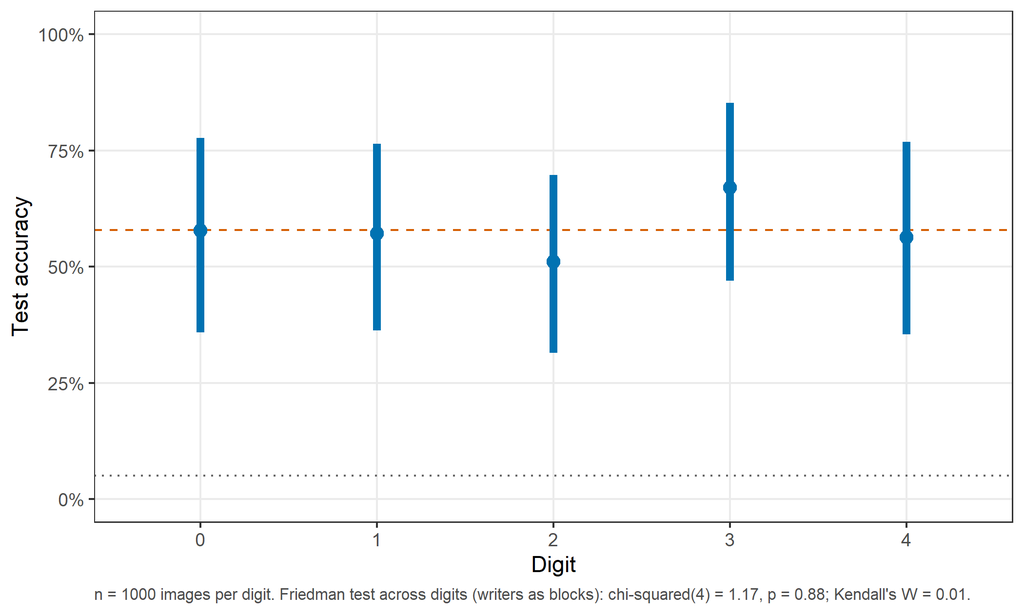

Figure 7: Test accuracy by digit. Thick blue line: 95% cluster-bootstrap interval (clusters = writers); thin grey line: exact Clopper-Pearson interval. Dotted line: chance (5%); dashed line: overall test accuracy.

```r
ggplot(digit_stats, aes(factor(Digit), Accuracy)) +
  geom_hline(yintercept = .05, linetype = 3, colour = "grey40") +
  geom_hline(yintercept = k_test / n_test, linetype = 2, colour = okabe[["red"]]) +
  geom_linerange(aes(ymin = CP_low, ymax = CP_high), colour = "grey60", linewidth = .6) +
  geom_linerange(aes(ymin = Boot_low, ymax = Boot_high), colour = okabe[["blue"]], linewidth = 1.8) +
  geom_point(size = 2.8, colour = okabe[["blue"]]) +
  scale_y_continuous(limits = c(0, 1), labels = scales::percent) +
  labs(x = "Digit", y = "Test accuracy",
       caption = sprintf("n = %d images per digit. Friedman test across digits (writers as blocks): chi-squared(%d) = %.2f, p %s; Kendall's W = %.2f.",
                         digit_stats$n[1], unname(fr2$parameter), unname(fr2$statistic), fp(fr2$p.value), w2))
```

```r
knitr::kable(digit_stats, digits = 3, row.names = FALSE,
             col.names = c("Digit", "n", "Accuracy", "CP low", "CP high", "Boot low", "Boot high"))
```

Table 6: Test accuracy by digit with exact Clopper-Pearson (CP) and cluster-bootstrap intervals.

| Digit | n | Accuracy | CP low | CP high | Boot low | Boot high |
| --- | --- | --- | --- | --- | --- | --- |
| 0 | 1000 | 0.578 | 0.547 | 0.609 | 0.359 | 0.777 |
| 1 | 1000 | 0.571 | 0.540 | 0.602 | 0.363 | 0.764 |
| 2 | 1000 | 0.511 | 0.480 | 0.542 | 0.315 | 0.697 |
| 3 | 1000 | 0.670 | 0.640 | 0.699 | 0.470 | 0.852 |
| 4 | 1000 | 0.563 | 0.532 | 0.594 | 0.354 | 0.768 |

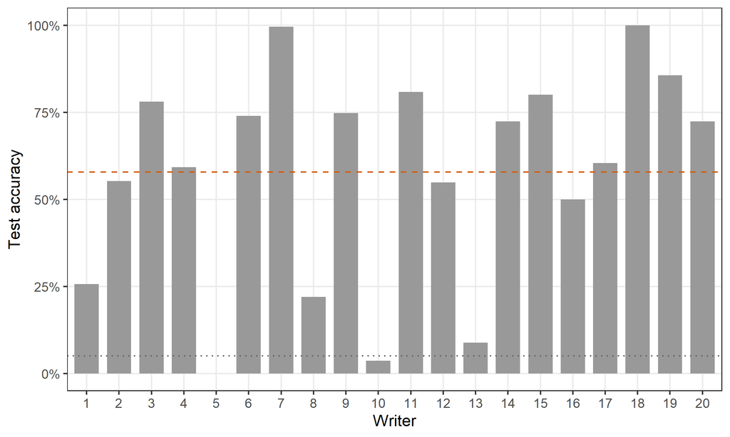

Figure 8: Test accuracy for each writer (50 images for each of 5 digits). Dotted line: chance (5%); dashed line: overall test accuracy.

```r
ggplot(writer_acc, aes(factor(Writer), Accuracy)) +
  geom_col(fill = "grey60", width = .75) +
  geom_hline(yintercept = .05, linetype = 3, colour = "grey40") +
  geom_hline(yintercept = k_test / n_test, linetype = 2, colour = okabe[["red"]]) +
  scale_y_continuous(limits = c(0, 1), labels = scales::percent) +
  labs(x = "Writer", y = "Test accuracy")
```

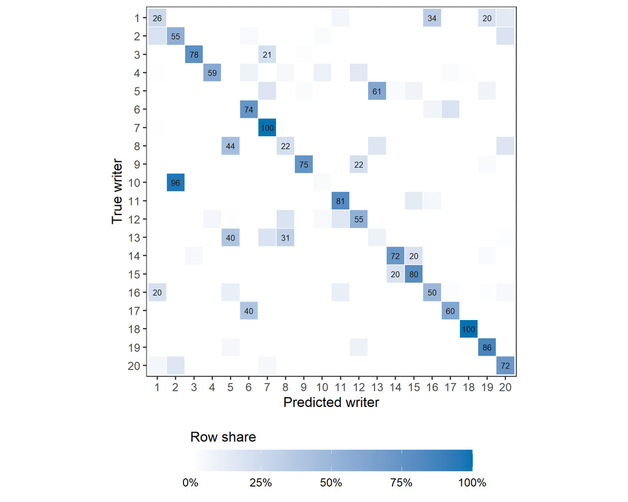

Figure 9: Confusion matrix on the test session. Each row is a true writer and shows the share of that writer’s images assigned to each predicted writer; cells with 20% or more are labelled with the percentage.

```r
ggplot(cm_df, aes(predicted, truth, fill = prop)) +
  geom_tile(colour = "white", linewidth = .25) +
  geom_text(data = subset(cm_df, prop >= .2), aes(label = round(100 * prop)), size = 2.3, colour = "grey10") +
  scale_fill_gradient(low = "white", high = okabe[["blue"]], limits = c(0, 1), labels = scales::percent, name = "Row share") +
  scale_y_discrete(limits = rev) +
  coord_fixed() +
  guides(fill = guide_colourbar(title.position = "top")) +
  theme(legend.key.width = unit(1.6, "cm")) +
  labs(x = "Predicted writer", y = "True writer")
```

```r
knitr::kable(top_conf, digits = 3, row.names = FALSE,
             col.names = c("True writer", "Predicted as", "Images", "Share of true writer's images"))
```

Table 7: The five most frequent single confusions on the test session.

| True writer | Predicted as | Images | Share of true writer’s images |
| --- | --- | --- | --- |
| 10 | 2 | 241 | 0.964 |
| 5 | 13 | 152 | 0.608 |
| 8 | 5 | 110 | 0.440 |
| 13 | 5 | 100 | 0.400 |
| 17 | 6 | 99 | 0.396 |

## 3.2 What Task 2 tells us

The CNN fitted the training sessions almost perfectly (98.5% accuracy after 10 epochs) but identified the writer correctly in only 57.9% of the test images from the unseen session 5 (Table 5). The exact Clopper-Pearson interval is 56.5% to 59.2%, but this treats the 5 000 images as independent, which they are not. The cluster bootstrap, which resamples whole writer-digit groups, gives a much wider interval of 48.9% to 66.9% (Saravanan et al., 2020), so the honest statement is that test accuracy is roughly 49% to 67%. Either way it is far above the 5% expected by chance, and far below the training accuracy. The learning curves show where the gap comes from (Figure 6). Validation accuracy stays between about 45% and 55% from the first epoch, while the validation loss rises from 1.78 to 4.22 as the training loss falls. The network is becoming more confident without becoming more correct on a new session, which is what overfitting looks like (Goodfellow et al., 2016). We did not use early stopping here, so the test result is for the model after 10 epochs.

The random split is the contrast that matters. The same network reached 99.4% validation accuracy within ten epochs when the images were shuffled across training and validation. That near-perfect score is not evidence of a better model. It is the leakage that Task 1 predicted, because the validation images have near-copies in the training set (the within-session distance was only 2.72). The gap of about 42 points between the random split (99.4%) and the session-split test (57.9%) shows how much a random split would have overstated performance (Roberts et al., 2017; Saeb et al., 2017).

Accuracy was similar across digits (51.1% to 67.0%), with digit 3 highest at 67.0%. The cluster-bootstrap intervals for the five digits overlap almost completely (Figure 7, Table 6), and a Friedman test across digits with writers as blocks gives chi-squared = 1.17 on 4 df, p = 0.88 (Kendall’s W = 0.01). The data therefore give little support for saying that some digits identify writers better than others, and the digit 3 result should be treated as a hint at most.

The errors are concentrated in particular writers more than in particular digits (Figure 8, Figure 9). The clearest case is writer 10: 241 of that writer’s 250 test images (96%) were assigned to writer 2 (Table 7). Writer 5 was mistaken for writer 13 in 61% of cases, and writer 13 for writer 5 in 40%, so those two seem to write alike in session 5. We only report this as an observation, because the matrix shows that it happens but not why.

In real-world terms, the model is given one digit from a known writer in a session it has not seen and must say who wrote it. The overall test accuracy of 57.9% means that, out of 100 new digits from known writers, about 58 are assigned to the right writer and about 42 to the wrong one, so the model has learned real writer information but still makes many mistakes. The results do not show how it would handle writers it has not seen, since it can only choose among the 20 known writers, or real handwriting, since the images are simulated.

# 4 Siamese network

**Training examples.** Positive pairs show the same writer and negative pairs show different writers, in roughly equal numbers. Both images in a pair show the same digit; otherwise the network could answer “different writer” whenever the digits differ, instead of comparing handwriting. We split by writer before building pairs: writers 1 to 14 for training (8 000 pairs), 15 to 17 for validation (2 000 pairs) and 18 to 20 for testing (2 000 pairs). Pairs are built only inside one part, so no image or writer appears in more than one part. Because the aim is to compare people, testing on unseen writers is the appropriate kind of generalisation.

**Loss.** We use the contrastive loss, which Siamese networks commonly use to learn distances (Chicco, 2021). With $D$ the distance between the two embeddings, $y = 1$ for a same-writer pair and $m = 1$ the margin,

$$L = y\,D^{2} + (1 - y)\,\max(0,\; m - D)^{2}.$$

Same-writer pairs are pulled together, and different-writer pairs are pushed apart only while they are closer than the margin. Some authors write the same loss with the labels reversed (0 for similar pairs); we follow the convention of the course slides. We optimised with Adam and early stopping on the validation loss, keeping the best weights.

**Evaluation.** The network outputs a distance, so a decision rule is needed: a pair is called “same writer” if its distance is below a threshold. We chose the threshold on the validation pairs to maximise balanced accuracy, the mean of the true match rate and the true non-match rate, which does not favour the more common pair type (Luque et al., 2019), and then fixed it for the test pairs. Because one threshold is one operating point, we also report the ROC curve, which plots the true match rate against the false match rate over all thresholds, and the area under it (AUC), the probability that a randomly chosen same-writer pair has a smaller distance than a randomly chosen different-writer pair. Intervals are percentile bootstrap intervals over test pairs (Efron & Hastie, 2016) and exact Clopper-Pearson intervals for rates (Agresti, 2019). These intervals reflect the sampling of pairs only. The pairs reuse a small set of images from three writers, so we also report results for each test writer separately.

## 4.1 Pair construction

```r
seed_all(1)

# 1. Split by WRITER first, so validation/test writers are never seen in training
tr_ids <- which(meta$person_id %in% 1:14)
va_ids <- which(meta$person_id %in% 15:17)
te_ids <- which(meta$person_id %in% 18:20)

# 2. Build pairs INSIDE one part. About half are same-writer (label 1), half
#    different-writer (label 0). Both images in a pair show the SAME digit, so
#    the model has to compare handwriting, not digit shape.
make_pairs <- function(ids, n){
  a <- sample(ids, n, replace = TRUE)
  same <- runif(n) < 0.5
  b <- integer(n)
  for (k in seq_len(n)){
    i <- a[k]
    pool <- ids[meta$digit[ids] == meta$digit[i]]
    pool <- if (same[k]) pool[meta$person_id[pool] == meta$person_id[i]]
            else         pool[meta$person_id[pool] != meta$person_id[i]]
    pool <- setdiff(pool, i)
    b[k] <- pool[sample.int(length(pool), 1)]
  }
  cbind(a, b)
}
make_batch <- function(p) list(
  left  = x[p[, 1], , , , drop = FALSE],
  right = x[p[, 2], , , , drop = FALSE],
  y     = matrix(as.numeric(meta$person_id[p[, 1]] == meta$person_id[p[, 2]]), ncol = 1))

tr_pairs <- make_pairs(tr_ids, 8000)
va_pairs <- make_pairs(va_ids, 2000)
te_pairs <- make_pairs(te_ids, 2000)   # keep the indices so test pairs can be analysed later
train <- make_batch(tr_pairs)
valid <- make_batch(va_pairs)
test  <- make_batch(te_pairs)
```

```r
pair_sets <- list(Training = tr_pairs, Validation = va_pairs, Test = te_pairs)
comp <- data.frame(
  Set = names(pair_sets),
  Writers = c("1-14", "15-17", "18-20"),
  Pairs = sapply(pair_sets, nrow),
  Same_writer_share = sapply(pair_sets, function(p) mean(meta$person_id[p[, 1]] == meta$person_id[p[, 2]])),
  Same_digit_in_pair = sapply(pair_sets, function(p) all(meta$digit[p[, 1]] == meta$digit[p[, 2]])),
  Distinct_images = sapply(pair_sets, function(p) length(unique(c(p)))))
knitr::kable(comp, digits = 3, row.names = FALSE,
             col.names = c("Set", "Writers", "Pairs", "Share same-writer", "Same digit in every pair", "Distinct images"))
```

Table 8: Composition of the pair sets. Images are never shared between sets because the split is by writer.

| Set | Writers | Pairs | Share same-writer | Same digit in every pair | Distinct images |
| --- | --- | --- | --- | --- | --- |
| Training | 1-14 | 8000 | 0.504 | TRUE | 10497 |
| Validation | 15-17 | 2000 | 0.498 | TRUE | 2490 |
| Test | 18-20 | 2000 | 0.478 | TRUE | 2475 |

```r
seed_all(1)   # fixed start weights and batch order for the Siamese network
# 3. Shared encoder: the same layers (same weights) are used for both images
img_in <- layer_input(shape = c(28, 28, 1))
z <- img_in |>
  layer_conv_2d(16, 3, activation = "relu") |>
  layer_max_pooling_2d(2) |>
  layer_conv_2d(32, 3, activation = "relu") |>
  layer_global_average_pooling_2d() |>
  layer_dense(16)
encoder <- keras_model(img_in, z)

# 4. Siamese model: output = Euclidean distance between the two embeddings
left_in  <- layer_input(shape = c(28, 28, 1))
right_in <- layer_input(shape = c(28, 28, 1))
emb_left  <- encoder(left_in)
emb_right <- encoder(right_in)
distance  <- op_sqrt(op_sum(op_square(emb_left - emb_right), axis = 2, keepdims = TRUE) + 1e-7)
siamese <- keras_model(list(left_in, right_in), distance)


# 5. Contrastive loss with margin 1:
#    same pairs (y = 1) are pulled together (loss D^2);
#    different pairs (y = 0) are pushed apart until D >= 1, then left alone.
contrastive_loss <- function(y, d) {
  op_mean(y * op_square(d) + (1 - y) * op_square(op_maximum(1 - d, 0)))
}
siamese |> compile(optimizer = optimizer_adam(1e-3), loss = contrastive_loss)

history_siam <- siamese |> fit(
  list(train$left, train$right), train$y,
  validation_data = list(list(valid$left, valid$right), valid$y),
  epochs = 12, batch_size = 64, verbose = 2,
  callbacks = list(callback_early_stopping(monitor = "val_loss", patience = 2,
                                           restore_best_weights = TRUE))
)
```

## 4.2 Threshold, test performance and breakdowns

```r
# 6. Choose the distance threshold on VALIDATION pairs (not on test)
valid_distance <- as.numeric(predict(siamese, list(valid$left, valid$right), verbose = 0))
valid_same <- valid$y[, 1] == 1

# balanced accuracy = average of (true match rate) and (true non-match rate)
bal_acc <- function(d, same, cut){
  pred_same <- d < cut
  (mean(pred_same[same]) + mean(!pred_same[!same])) / 2
}
# AUC = P(a same-writer pair has a smaller distance than a different-writer pair)
auc_dist <- function(d, same){
  r <- rank(d); n1 <- sum(same); n0 <- sum(!same)
  1 - (sum(r[same]) - n1 * (n1 + 1) / 2) / (n1 * n0)
}

cuts <- seq(min(valid_distance), max(valid_distance), length.out = 200)
scores <- sapply(cuts, function(cc) bal_acc(valid_distance, valid_same, cc))
threshold <- cuts[which.max(scores)]
c(threshold = threshold, validation_balanced_accuracy = max(scores))

# 7. Evaluate once on TEST pairs (new writers), threshold fixed from validation
test_distance <- as.numeric(predict(siamese, list(test$left, test$right), verbose = 0))
test_same <- test$y[, 1] == 1
pred_same <- test_distance < threshold

c(test_balanced_accuracy = bal_acc(test_distance, test_same, threshold),
  true_match_rate        = mean(pred_same[test_same]),
  true_non_match_rate    = mean(!pred_same[!test_same]))

table(truth = test_same, predicted = pred_same)
```

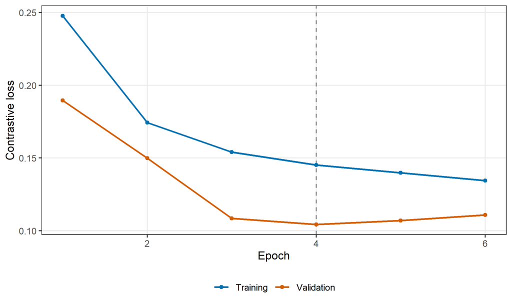

Figure 10: Contrastive loss by epoch for the training and validation pairs. Early stopping restores the weights from the epoch with the lowest validation loss (dashed line).

```r
h3 <- data.frame(epoch = rep(seq_along(history_siam$metrics$loss), 2),
                 set = rep(c("Training", "Validation"), each = length(history_siam$metrics$loss)),
                 loss = c(history_siam$metrics$loss, history_siam$metrics$val_loss))
ggplot(h3, aes(epoch, loss, colour = set)) +
  geom_vline(xintercept = which.min(history_siam$metrics$val_loss), linetype = 2, colour = "grey50") +
  geom_line(linewidth = .8) + geom_point(size = 1.5) +
  scale_colour_manual(values = c(Training = okabe[["blue"]], Validation = okabe[["red"]]), name = NULL) +
  labs(x = "Epoch", y = "Contrastive loss")
```

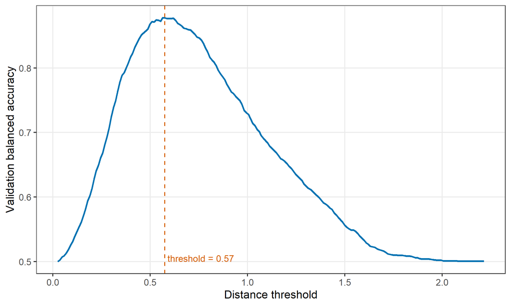

Figure 11: Choosing the threshold: balanced accuracy on the validation pairs for each candidate distance threshold. The dashed line marks the chosen threshold.

```r
ggplot(data.frame(cut = cuts, score = scores), aes(cut, score)) +
  geom_line(linewidth = .8, colour = okabe[["blue"]]) +
  geom_vline(xintercept = threshold, linetype = 2, colour = okabe[["red"]]) +
  annotate("text", x = threshold, y = min(scores), label = sprintf(" threshold = %.2f", threshold),
           hjust = 0, vjust = 0, size = 3.2, colour = okabe[["red"]]) +
  labs(x = "Distance threshold", y = "Validation balanced accuracy")
```

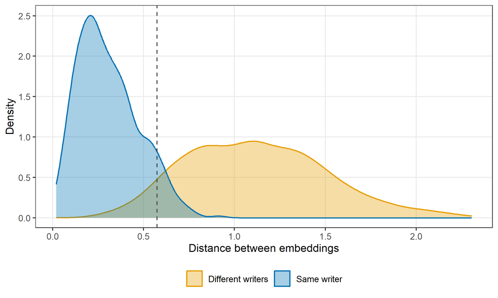

Figure 12: Distribution of the embedding distance for the 2 000 test pairs (unseen writers), by true pair type. The dashed line is the threshold chosen on the validation pairs.

```r
ggplot(data.frame(d = test_distance, Pair = ifelse(test_same, "Same writer", "Different writers")),
       aes(d, fill = Pair, colour = Pair)) +
  geom_density(alpha = .35, linewidth = .6) +
  geom_vline(xintercept = threshold, linetype = 2, colour = "grey25") +
  scale_fill_manual(values = c("Same writer" = okabe[["blue"]], "Different writers" = okabe[["orange"]]), name = NULL) +
  scale_colour_manual(values = c("Same writer" = okabe[["blue"]], "Different writers" = okabe[["orange"]]), name = NULL) +
  labs(x = "Distance between embeddings", y = "Density")
```

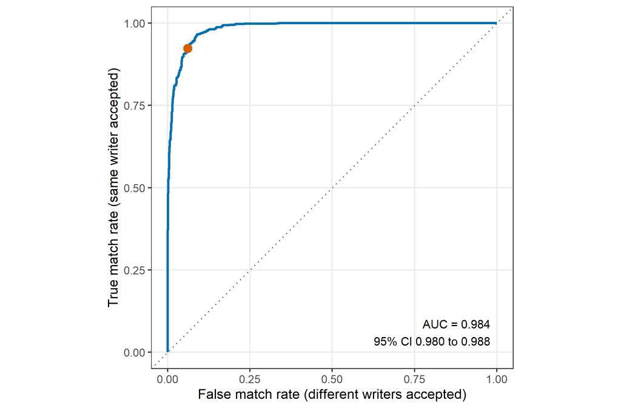

Figure 13: ROC curve for the test pairs. The orange point is the operating point at the chosen threshold; the dotted diagonal is chance.

```r
ggplot(roc, aes(fpr, tpr)) +
  geom_abline(linetype = 3, colour = "grey50") +
  geom_path(linewidth = .9, colour = okabe[["blue"]]) +
  geom_point(data = data.frame(fpr = 1 - tnr_k / tnr_n, tpr = tmr_k / tmr_n), size = 3, colour = okabe[["red"]]) +
  annotate("text", x = .98, y = .06, hjust = 1, size = 3.4,
           label = sprintf("AUC = %.3f\n95%% CI %.3f to %.3f", auc_hat,
                           quantile(boot_t3[, "auc"], .025), quantile(boot_t3[, "auc"], .975))) +
  coord_equal() +
  labs(x = "False match rate (different writers accepted)", y = "True match rate (same writer accepted)")
```

```r
knitr::kable(t3_metrics, digits = 3, row.names = FALSE,
             col.names = c("Measure", "Estimate", "CI low", "CI high", "Interval type"))
```

Table 9: Test performance of the Siamese network at the validation-chosen threshold. Bootstrap intervals resample test pairs; Clopper-Pearson intervals are exact binomial intervals. Both treat pairs as independent.

| Measure | Estimate | CI low | CI high | Interval type |
| --- | --- | --- | --- | --- |
| Balanced accuracy | 0.931 | 0.919 | 0.942 | Bootstrap |
| True match rate (same writer accepted) | 0.923 | 0.904 | 0.939 | Clopper-Pearson |
| True non-match rate (different writer rejected) | 0.939 | 0.922 | 0.953 | Clopper-Pearson |
| AUC | 0.984 | 0.980 | 0.988 | Bootstrap |

```r
knitr::kable(t3_conf, row.names = FALSE, col.names = c("True pair type", "Accepted as same writer", "Rejected as different"))
```

Table 10: Test decisions at the chosen threshold.

| True pair type | Accepted as same writer | Rejected as different |
| --- | --- | --- |
| Same writer | 881 | 74 |
| Different writers | 64 | 981 |

```r
sess_out <- sess_tab
knitr::kable(sess_out, digits = 3, row.names = FALSE,
             col.names = c("True pair type", "Sessions", "n pairs", "Correct", "Rate", "CI low", "CI high"))
```

Table 11: Correct decisions by true pair type and whether the two images come from the same session, with exact 95% Clopper-Pearson intervals.

| True pair type | Sessions | n pairs | Correct | Rate | CI low | CI high |
| --- | --- | --- | --- | --- | --- | --- |
| Same writer | Same session | 200 | 200 | 1.000 | 0.982 | 1.000 |
| Same writer | Different sessions | 755 | 681 | 0.902 | 0.879 | 0.922 |
| Different writers | Same session | 187 | 173 | 0.925 | 0.878 | 0.958 |
| Different writers | Different sessions | 858 | 808 | 0.942 | 0.924 | 0.956 |

```r
cat(sprintf("Fisher exact test, same versus different sessions: same-writer pairs p %s; different-writer pairs p %s.\n",
            if (is.na(p_same_writer_sessions)) "= NA" else fp(p_same_writer_sessions),
            if (is.na(p_diff_writer_sessions)) "= NA" else fp(p_diff_writer_sessions)))
```

Fisher exact test, same versus different sessions: same-writer pairs p = 1.9e-08; different-writer pairs p = 0.4.

```r
knitr::kable(by_writer, digits = 3, row.names = FALSE,
             col.names = c("Writer", "Pairs", "Same-writer pairs", "TMR", "TNR", "Balanced accuracy", "AUC"))
```

Table 12: Test performance by the writer of the first image in each pair (writers 18 to 20). TMR: true match rate; TNR: true non-match rate.

| Writer | Pairs | Same-writer pairs | TMR | TNR | Balanced accuracy | AUC |
| --- | --- | --- | --- | --- | --- | --- |
| 18 | 664 | 316 | 0.949 | 0.977 | 0.963 | 0.996 |
| 19 | 665 | 311 | 0.910 | 0.941 | 0.925 | 0.984 |
| 20 | 671 | 328 | 0.909 | 0.898 | 0.903 | 0.969 |

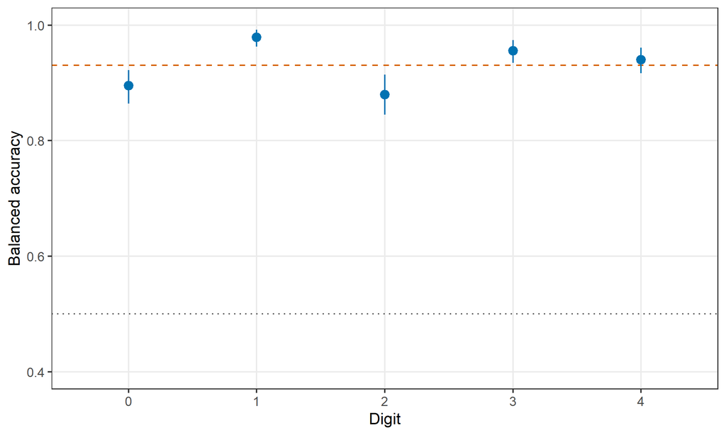

Figure 14: Test balanced accuracy by digit (the digit is the same in both images of a pair), with 95% bootstrap intervals over pairs. Dashed line: overall test balanced accuracy; dotted line: chance (0.5).

```r
ggplot(by_digit, aes(factor(Digit), Bal_acc)) +
  geom_hline(yintercept = .5, linetype = 3, colour = "grey40") +
  geom_hline(yintercept = bal_hat, linetype = 2, colour = okabe[["red"]]) +
  geom_pointrange(aes(ymin = CI_low, ymax = CI_high), colour = okabe[["blue"]], size = .5) +
  scale_y_continuous(limits = c(.4, 1)) +
  labs(x = "Digit", y = "Balanced accuracy")
```

## 4.3 What Task 3 tells us

On three writers the network never saw during training, the Siamese network separated same-writer from different-writer pairs well. At the distance threshold of 0.57 chosen on the validation pairs, balanced accuracy on the test pairs was 0.931 (95% bootstrap CI 0.919 to 0.942), with a true match rate of 0.923 and a true non-match rate of 0.939 (Table 9, Table 10). The AUC of 0.984 (95% CI 0.980 to 0.988) shows that the ranking of pairs by distance is good over all thresholds, not only at the one chosen (Figure 13, Figure 12). Early stopping kept the weights from epoch 4 (validation loss 0.104) and stopped at epoch 6 (Figure 10). The test balanced accuracy is higher than the 0.878 seen on the validation pairs at the chosen threshold. With only three writers in each of the two sets, that difference could come from which writers happened to be in each set, so we do not read anything into it.

Task 1 predicted that pairs from different sessions would be harder, and the session breakdown shows this for same-writer pairs (Table 11). Of the 200 same-writer pairs from the same session, 200 were accepted (100%, exact CI 98.2% to 100%), against 90.2% (681 of 755) for same-writer pairs from different sessions (Fisher exact p = 1.9e-08). For different-writer pairs there was no clear session effect (92.5% against 94.2%, p = 0.4). In other words, the network is least sure when asked to connect two sessions of one person, which is the case the application cares about. The same-session figure is also not independent evidence, since those images are near-copies.

Performance differed a little between the three test writers (balanced accuracy 0.963, 0.925 and 0.903 for writers 18, 19 and 20; Table 12), and between digits (Figure 14). With three writers and the pairs sharing images (2 000 test pairs use 2 475 distinct images, Table 8), the intervals in Table 9 are likely to be too narrow, so they should be read as the lower bound on the uncertainty.

# 5 Train, validation and test strategy

For the CNN we split by session. Sessions 1 to 3 (15 000 images) were used for training, session 4 (5 000 images) for validation and session 5 (5 000 images) for testing, so each writer, digit and session group of 50 images sits in exactly one set. The training set fits the weights, the validation set is used to monitor and compare models, and the test set was used once, for the final result.

We split by session and not at random because the 50 replicates of a writer, digit and session are near copies of each other (Task 1: mean within-session distance 2.72). In a random split, near copies of the test images sit in the training set, so the model is rewarded for remembering and not for generalising. This is the leakage problem that is known for grouped data (Kapoor & Narayanan, 2023; Roberts et al., 2017). Splitting by session keeps each group of copies on one side. We did not split by writer for the CNN, because a classifier with 20 output classes can only name writers it was trained on.

We checked this with a random split of the same size. Validation accuracy was 54.5% on the session split and 99.4% on the random split, so the random split overstated performance by about 45 percentage points. The session-split results still have limits: all 20 writers are in the training data, the images are simulated, and everything rests on one test session, so another session could give a different accuracy.

For the Siamese network we split by writer before making pairs: writers 1 to 14 (8 000 pairs) for training, 15 to 17 (2 000 pairs) for validation and 18 to 20 (2 000 pairs) for testing. No writer or image appears in more than one set, so the test measures verification of unseen people, which is a different question from the CNN’s. The threshold was chosen on the validation pairs and fixed before testing. The validation pairs were also used for early stopping, so the validation score (0.878) is slightly optimistic. The test score was 0.931, and the gap between the two most likely reflects which writers fell in each set, since each set has only a few writers.

Two features of the Siamese test need care. First, only 21% of the same-writer test pairs come from one session, but those pairs are near copies and were always accepted (200 of 200), which lifts the overall score. On different-session pairs alone the balanced accuracy was 0.922, against 0.931 overall. Second, the 2 000 test pairs reuse 2 475 images from three writers, so pair-based intervals are too narrow, and the balanced accuracy ranged from 0.903 to 0.963 across the three writers (Table 12). Finally, because the images are simulated and each pair shows one digit, performance on real handwriting or on pairs of different digits may be lower.

# 6 Hyperparameter optimisation

```r
seed_all(1)
#model builder (base)
build_cnn <- function(filters = 32, dropout = 0.3, lr = 0.001){
  m <- keras_model_sequential(input_shape = c(28, 28, 1)) |>
    layer_conv_2d(filters = filters, kernel_size = 3, activation = "relu") |>
    layer_max_pooling_2d(pool_size = 2) |>
    layer_conv_2d(filters = filters * 2, kernel_size = 3, activation = "relu") |>
    layer_max_pooling_2d(pool_size = 2) |>
    layer_flatten() |>
    layer_dense(units = 64, activation = "relu") |>
    layer_dropout(rate = dropout) |>
    layer_dense(units = 20, activation = "softmax")
  m |> compile(
    loss = "sparse_categorical_crossentropy",
    optimizer = optimizer_adam(learning_rate = lr),
    metrics = "accuracy"
  )
  m
}
# varying 3 learning rates and 3 filter sizes = 9 model combinations
grid <- expand.grid(lr = c(0.0003, 0.001, 0.003),
                    filters = c(16, 32, 64))
is_base <- grid$lr == 0.001 & grid$filters == 32
epochs_used <- 10


#modelling
models <- vector("list", nrow(grid))

for (g in seq_len(nrow(grid))){
  if (is_base[g]){
    models[[g]] <- model        #trained baseline CNN (learning rate = 0.001) Task 2
    next
  }
  seed_all(1)   # same seed for every grid model
  models[[g]] <- build_cnn(filters = grid$filters[g], lr = grid$lr[g])
  models[[g]] |> fit(x_train, y_train,
                     epochs = epochs_used, batch_size = 128, verbose = 0)
  cat("trained", g, "of", nrow(grid), "\n")
}


#validation accuracy overall and by digit, for every model
meta_val  <- meta[val_rows, ]
digit_acc <- matrix(NA, nrow(grid), 5,
                    dimnames = list(NULL, paste0("Digit_", 0:4)))
grid$val_acc <- NA

for (g in seq_len(nrow(grid))){
  pred_class <- max.col(models[[g]] |> predict(x_val, verbose = 0)) - 1L
  correct    <- pred_class == y_val
  grid$val_acc[g] <- round(100 * mean(correct), 1)
  digit_acc[g, ]  <- round(100 * tapply(correct, meta_val$digit, mean), 1)
}

grid_digit <- cbind(grid, digit_acc)
dir.create("results", showWarnings = FALSE)
saveRDS(grid, "results/task5_grid.rds")
saveRDS(grid_digit, "results/task5_grid_digit.rds")
grid_digit


#sensitivity
range(grid$val_acc)
diff(range(grid$val_acc))              # spread across all 9 settings

tapply(grid$val_acc, grid$lr, mean)           # average by learning rate
tapply(grid$val_acc, grid$filters, mean)      # average by number of filters


#per-digit validation accuracy for the best model
best <- which.max(grid$val_acc)
grid[best, ]

pred_best  <- max.col(models[[best]] |> predict(x_val, verbose = 0)) - 1L
acc_digit_best <- tapply(pred_best == y_val, meta[val_rows, ]$digit, mean)
round(100 * acc_digit_best, 1)
saveRDS(acc_digit_best, "results/task5_best_by_digit.rds")
```

Hyperparameter optimisation of the CNN was done with a grid search, which tries every combination of a fixed set of values. Results can depend strongly on a few hyperparameters, which is why tuning is worth checking (Probst et al., 2019); other search methods exist (Bischl et al., 2023), but a small grid was enough for this brief. Optimisation was conducted by varying three values of the learning rate as well as three values of the number of filters while keeping all other hyperparameters constant. The learning rate controls how fast the model can learn and process before updating the weights while the number of filters sets how many patterns each convolution layer can pick up (Goodfellow et al., 2016). The number of filters was set to 16, 32 and 64 and the learning rate to 0.0003, 0.001 and 0.003, which gives 9 combinations. The baseline CNN from Section 3 used the Adam optimiser with its default learning rate of 0.001 and had 32 filters in the first convolution layer and 64 in the second. The sensitivity to the hyperparameters was measured using the overall validation accuracy and the per-digit validation accuracy as in task 2.

```r
grid <- readRDS("results/task5_grid.rds")

m <- tapply(grid$val_acc, list(grid$lr, grid$filters), mean)   # rows = learning rate, columns = filters
m <- rbind(m, Mean = colMeans(m))                               # average over learning rates
m <- cbind(m, Mean = rowMeans(m))                               # average over filter sizes (corner = overall mean)

rownames(m)[1:3] <- sprintf("%.4f", as.numeric(rownames(m)[1:3]))
colnames(m)[1:3] <- paste(colnames(m)[1:3], "filters")

knitr::kable(m, digits = 1, align = "cccc")
```

Table 13: Overall validation accuracy (%) on session 4 for each combination of learning rate and number of filters, with row and column means. The baseline CNN uses a learning rate of 0.0010 and 32 filters.

|  | 16 filters | 32 filters | 64 filters | Mean |
| --- | --- | --- | --- | --- |
| 0.0003 | 52.7 | 53.2 | 52.4 | 52.8 |
| 0.0010 | 49.4 | 54.5 | 50.9 | 51.6 |
| 0.0030 | 50.3 | 52.9 | 49.2 | 50.8 |
| Mean | 50.8 | 53.5 | 50.8 | 51.7 |

Overall validation accuracy ranged from 49.2% to 54.5% across the nine settings (mean 51.7%, SD 1.8; Table 13). The best setting was a learning rate of 0.0010 with 32 filters at 54.5% (the baseline configuration), and the worst was a learning rate of 0.0030 with 64 filters at 49.2%, a spread of 5.3 percentage points. Averaged over the other hyperparameter, validation accuracy was 52.8%, 51.6% and 50.8% for learning rates of 0.0003, 0.001 and 0.003, and 50.8%, 53.5% and 50.8% for 16, 32 and 64 filters. The ranges of these averages are 2.0 and 2.7 percentage points, so accuracy was more sensitive to the number of filters. With 5 000 validation images the binomial standard error of an accuracy near 51.7% is about 0.7 percentage points, and the images are clustered by writer, so the true uncertainty is larger and differences of one or two points between settings should not be interpreted. Each setting was trained once with the same seed. The size of the gain from tuning differs between hyperparameters and between data sets, which is why tuning effort is usually focused on the few that matter most (Probst et al., 2019). No setting stands out: none is more than 3 points below the mean.

```r
gd   <- readRDS("results/task5_grid_digit.rds")
cols <- c("val_acc", paste0("Digit_", 0:4))

tab <- data.frame(`Learning rate` = sprintf("%.4f", gd$lr),
                  Filters = as.character(gd$filters),
                  gd[, cols], check.names = FALSE)

avg <- data.frame(`Learning rate` = "Mean", Filters = "all",
                  t(colMeans(gd[, cols])), check.names = FALSE)

tab <- rbind(tab, avg)
names(tab)[3:8] <- c("Overall", paste("Digit", 0:4))

knitr::kable(tab, digits = 1, align = rep("c", 8), row.names = FALSE)
```

Table 14: Validation accuracy (%) on session 4, overall and by digit, for each combination of learning rate and number of filters. The last row is the mean across the nine settings.

| Learning rate | Filters | Overall | Digit 0 | Digit 1 | Digit 2 | Digit 3 | Digit 4 |
| --- | --- | --- | --- | --- | --- | --- | --- |
| 0.0003 | 16 | 52.7 | 54.8 | 55.7 | 49.2 | 59.4 | 44.4 |
| 0.0010 | 16 | 49.4 | 52.2 | 53.9 | 43.2 | 56.9 | 40.8 |
| 0.0030 | 16 | 50.3 | 49.1 | 50.0 | 51.5 | 62.2 | 38.9 |
| 0.0003 | 32 | 53.2 | 42.2 | 59.1 | 47.9 | 61.0 | 55.9 |
| 0.0010 | 32 | 54.5 | 46.4 | 63.6 | 46.4 | 66.3 | 50.0 |
| 0.0030 | 32 | 52.9 | 51.2 | 53.2 | 50.1 | 67.6 | 42.5 |
| 0.0003 | 64 | 52.4 | 49.4 | 56.3 | 52.9 | 63.0 | 40.4 |
| 0.0010 | 64 | 50.9 | 48.0 | 53.5 | 52.8 | 55.2 | 44.9 |
| 0.0030 | 64 | 49.2 | 38.5 | 63.3 | 54.4 | 55.2 | 34.8 |
| Mean | all | 51.7 | 48.0 | 56.5 | 49.8 | 60.8 | 43.6 |

In Table 14, the mean validation accuracy over the nine settings was highest for digit 3 (60.8%) and digit 1 (56.5%) and lowest for digit 4 (43.6%) and digit 0 (48.0%). The order of the digits was consistent across settings (Friedman chi-squared = 28.7 on 4 df, p = 8.9e-06; Kendall’s W = 0.80; settings as blocks). The nine models share the same data, so this shows a stable ordering and not independent replication.

# 7 Comparison and discussion

## 7.1 What the two models measure

The CNN does identification: given one image it picks one of 20 known writers, so chance is 5%. The Siamese network does verification: given two images it decides whether one writer wrote both, so chance is 50%, and the test writers were never seen in training (Chicco, 2021). The results in Table 15 therefore answer different questions and should not be ranked against each other. The CNN named the right writer for 57.9% of the session 5 images, about 12 times chance, and the Siamese network reached a balanced accuracy of 0.931 with an AUC of 0.984. Choosing between two outcomes is easier than choosing among 20, so the higher Siamese score does not mean that it recognises writers better. The uncertainty also differs. The CNN interval comes from a cluster bootstrap that resamples writer-digit groups, which respects the dependence between near-copy images (Saravanan et al., 2020). The Siamese intervals resample pairs that share images, so they are too narrow and are best read as a lower bound. The cluster bootstrap itself can be conservative when the data are closer to independent than assumed (Saravanan et al., 2020), so the CNN interval errs on the side of being too wide, which is the safer mistake here.

```r
cmp_models <- data.frame(
  Item = c("Question", "Held-out data", "Chance level", "Main result"),
  CNN = c("Which of the 20 writers wrote this image?",
          sprintf("Session 5, known writers (%s images)", sp(n_test)),
          "0.05",
          sprintf("Accuracy %.3f (CP %.3f to %.3f; cluster bootstrap %.3f to %.3f)", test_acc, cp_all[1], cp_all[2], boot_all[1], boot_all[2])),
  Siamese = c("Did one writer write both images?",
              sprintf("Writers 18 to 20, unseen (%s pairs)", sp(n_pairs)),
              "0.50",
              sprintf("Balanced accuracy %.3f (%.3f to %.3f); AUC %.3f (%.3f to %.3f)", bal_hat, bal_ci[1], bal_ci[2], auc_hat, auc_ci[1], auc_ci[2])))
knitr::kable(cmp_models, row.names = FALSE, col.names = c("", "CNN (identification)", "Siamese network (verification)"))
```

Table 15: Summary of the two models on their held-out data. CP: exact Clopper-Pearson interval.

|  | CNN (identification) | Siamese network (verification) |
| --- | --- | --- |
| Question | Which of the 20 writers wrote this image? | Did one writer write both images? |
| Held-out data | Session 5, known writers (5 000 images) | Writers 18 to 20, unseen (2 000 pairs) |
| Chance level | 0.05 | 0.50 |
| Main result | Accuracy 0.579 (CP 0.565 to 0.592; cluster bootstrap 0.489 to 0.669) | Balanced accuracy 0.931 (0.919 to 0.942); AUC 0.984 (0.980 to 0.988) |

## 7.2 Which digits carry more writer information

```r
cmp <- data.frame(
  Digit = 0:4,
  cnn_test = sprintf("%.1f (%.1f to %.1f)", 100 * digit_stats$Accuracy, 100 * digit_stats$Boot_low, 100 * digit_stats$Boot_high),
  cnn_val9 = sprintf("%.1f", val9),
  siam     = sprintf("%.3f (%.3f to %.3f)", by_digit$Bal_acc, by_digit$CI_low, by_digit$CI_high),
  ratio    = sprintf("%.2f", rd$Ratio))
knitr::kable(cmp, row.names = FALSE, align = "ccccc",
             col.names = c("Digit", "CNN test accuracy", "CNN validation, mean of 9 settings",
                           "Siamese balanced accuracy", "Across / within distance"))
```

Table 16: Writer information by digit. CNN test accuracy (%) with 95% cluster-bootstrap interval; mean CNN validation accuracy (%) over the nine tuning settings; Siamese balanced accuracy on test pairs with 95% bootstrap interval; and the Task 1 ratio of across-session to within-session pixel distance.

| Digit | CNN test accuracy | CNN validation, mean of 9 settings | Siamese balanced accuracy | Across / within distance |
| --- | --- | --- | --- | --- |
| 0 | 57.8 (35.9 to 77.7) | 48.0 | 0.895 (0.864 to 0.922) | 2.56 |
| 1 | 57.1 (36.3 to 76.4) | 56.5 | 0.979 (0.962 to 0.992) | 3.40 |
| 2 | 51.1 (31.5 to 69.7) | 49.8 | 0.880 (0.845 to 0.914) | 2.54 |
| 3 | 67.0 (47.0 to 85.2) | 60.8 | 0.955 (0.935 to 0.974) | 2.56 |
| 4 | 56.3 (35.4 to 76.8) | 43.6 | 0.940 (0.916 to 0.961) | 2.36 |

The evidence that digits differ is weaker than the rankings suggest. For the CNN test accuracy, a Friedman test with writers as blocks gave chi-squared = 1.17 on 4 df, p = 0.88 (Kendall’s W = 0.01), and the bootstrap intervals overlap almost completely. Across the nine tuning settings the ordering of digits was more consistent (Friedman chi-squared = 28.7 on 4 df, p = 8.9e-06; W = 0.80). However, those nine models share the same training and validation images, so this shows a stable ordering within one data set and not that it would reappear for new writers. The pixel distances of Task 1 did not predict the ranking either: digit 1 had the largest across-session to within-session ratio (3.40), yet it ranked third for CNN test accuracy and first for the Siamese network. Taken together, digit 3 carried the most writer information in this data set, every digit carried far more than chance, and the differences between digits are small next to the differences between writers (Figure 8).

## 7.3 How a change of session affects performance

Task 1 showed that a change of session moves a writer’s digit about 75% of the way towards another writer’s digit, and both models paid for it. The CNN fitted its training sessions to 98.5% and the randomly split validation images to 99.4%, where near copies were in the training set. On the new sessions it reached 54.5% (session 4) and 57.9% (session 5), a drop of about 41 points from training. The session 4 accuracy lies inside the session 5 bootstrap interval, so the two held-out sessions cannot be told apart. The validation loss rose from 1.78 to 4.22 while the training loss fell, which is the usual sign of overfitting (Goodfellow et al., 2016).

The Siamese network shows the same effect more precisely. All 200 same-writer pairs from one session were accepted, against 90.2% of the 755 same-writer pairs from different sessions (Fisher exact p = 1.9e-08; Table 11). Different-writer pairs showed no clear session effect (92.5% against 94.2%, p = 0.4). A change of session therefore caused false rejections of the same writer and not false matches. The Fisher test treats pairs as independent, so its p-value is too small, but the gap is large. The drops (about 41 points for the CNN and 9.8 points in the Siamese true match rate) cannot be compared directly because the tasks and writers differ. Their direction agrees with the evidence that testing on near copies of the training data overstates performance (Kapoor & Narayanan, 2023; Roberts et al., 2017; Saeb et al., 2017).

## 7.4 Limitations and summary

The data are simulated, the CNN result rests on one held-out session, and the Siamese result rests on three writers. Each model was trained once with a fixed seed, so seed-to-seed variation was not measured. The nine tuning settings spanned 5.3 percentage points, and with 5 000 validation images the binomial standard error of an accuracy near 51.7% is about 0.7 points before dependence is allowed for, so differences of one or two points between settings should not be interpreted. The two models were also not compared on the same footing. A fairer test would score both on the same pairs, for example by using the CNN’s hidden layer as an embedding.

In summary, a CNN trained on sessions 1 to 3 identified the writer in 57.9% of the images from a new session, far above the 5% chance level but well below its training accuracy. A Siamese network separated same-writer from different-writer pairs of unseen writers with a balanced accuracy of 0.931. Digit 3 carried the most writer information, but the differences between digits were small. A change of session lowered performance in both models, mainly by making the same writer look like a different one.

# 8 Appendices

## 8.1 Appendix A: Data exploration figures not shown in Section 2

The main text shows digits 0 and 1 for the writer and session comparisons and digit 1 for the replicate comparison (Section 2). The figures below show the remaining digits with the same settings, so that all five digits are covered.

```r
plot_writers(2)
plot_writers(3)
plot_writers(4)
```

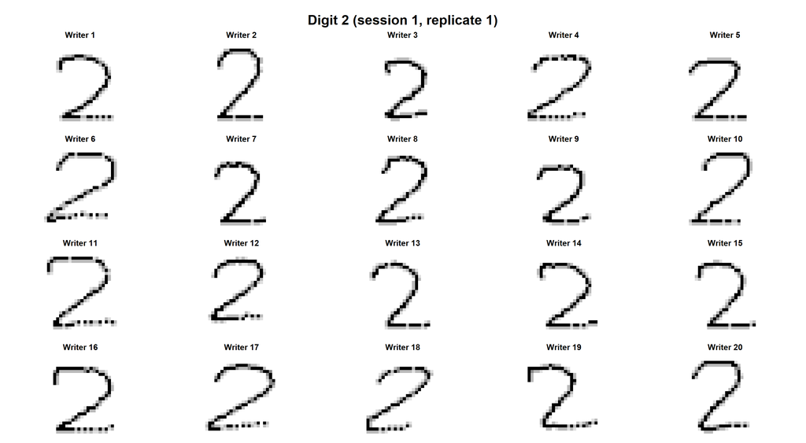

(a) Digit 2

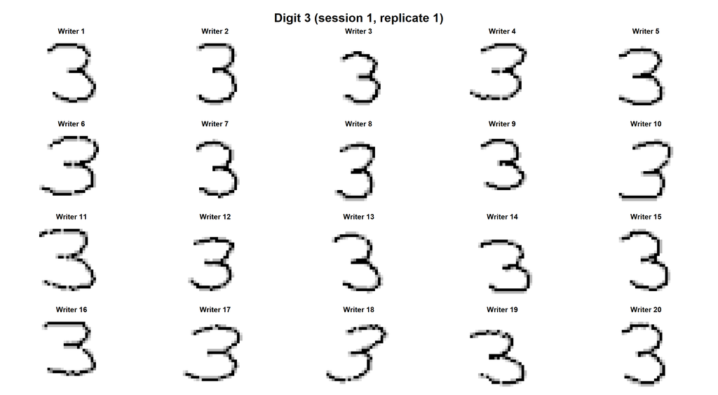

(b) Digit 3

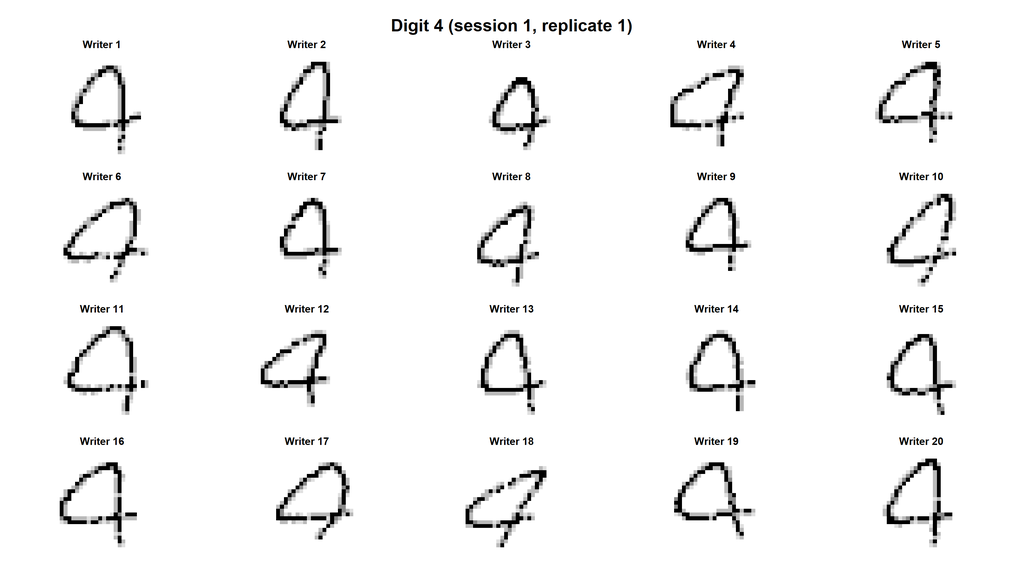

(c) Digit 4

Figure 15: Digits 2, 3 and 4 for all 20 writers, with session 1 and replicate 1 fixed.

```r
plot_sessions_sample(2)
plot_sessions_sample(3)
plot_sessions_sample(4)
```

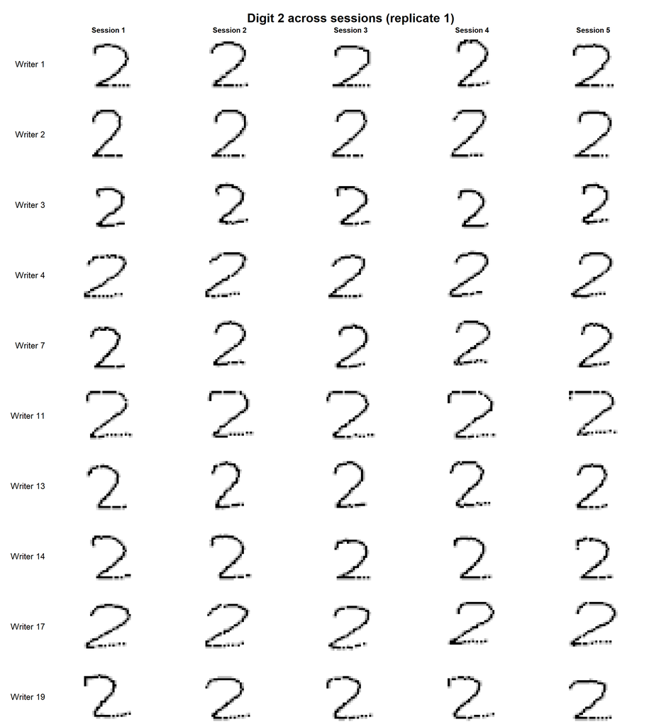

(a) Digit 2

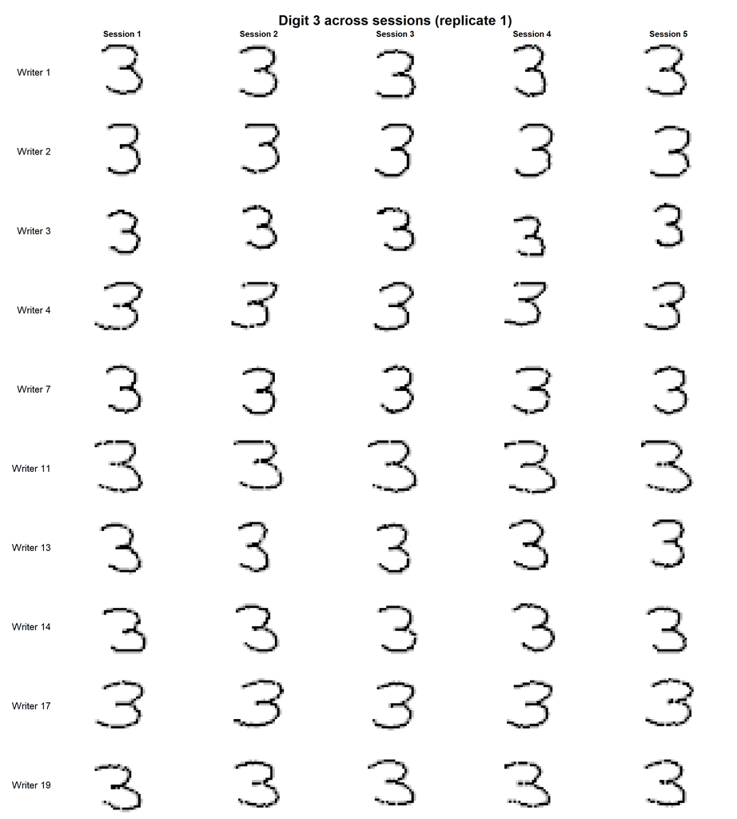

(b) Digit 3

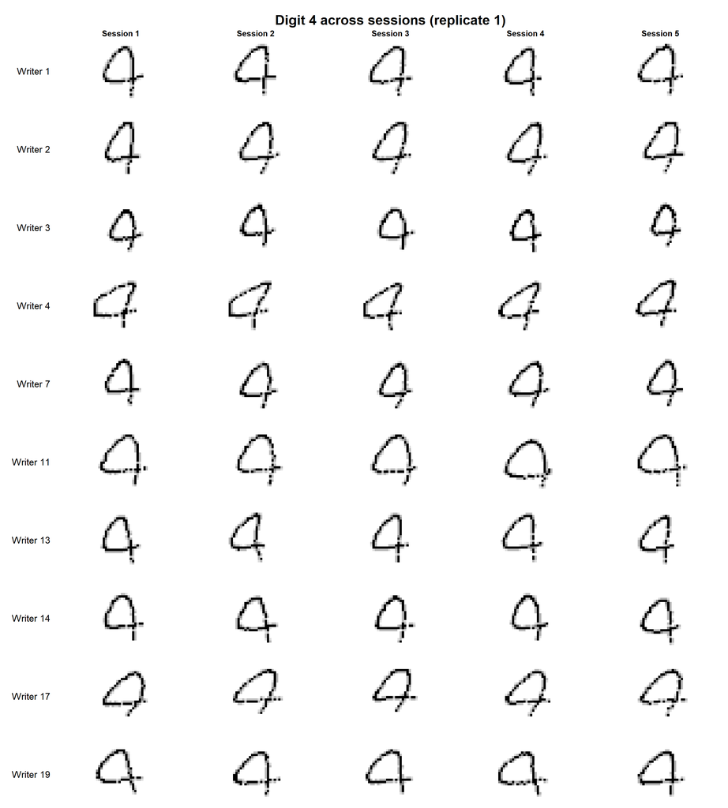

(c) Digit 4

Figure 16: Digits 2, 3 and 4 for the same ten randomly sampled writers as in the sessions figure (seed 1), with replicate 1 fixed. Rows are writers and columns are sessions 1 to 5.

```r
plot_replicates(0)
plot_replicates(2)
plot_replicates(3)
plot_replicates(4)
```

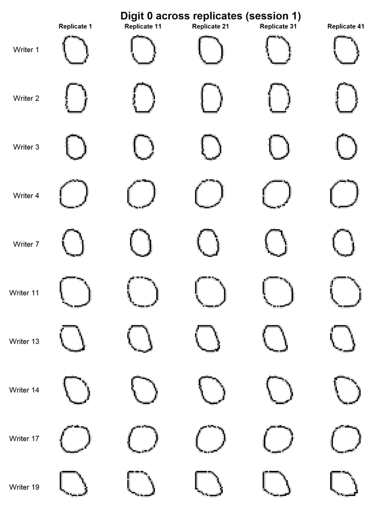

(a) Digit 0

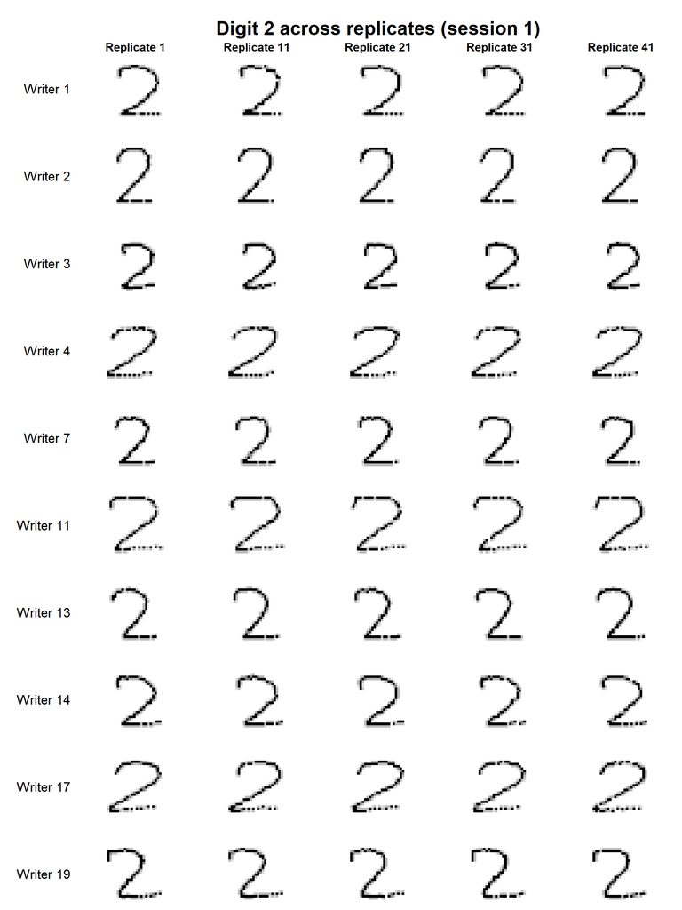

(b) Digit 2

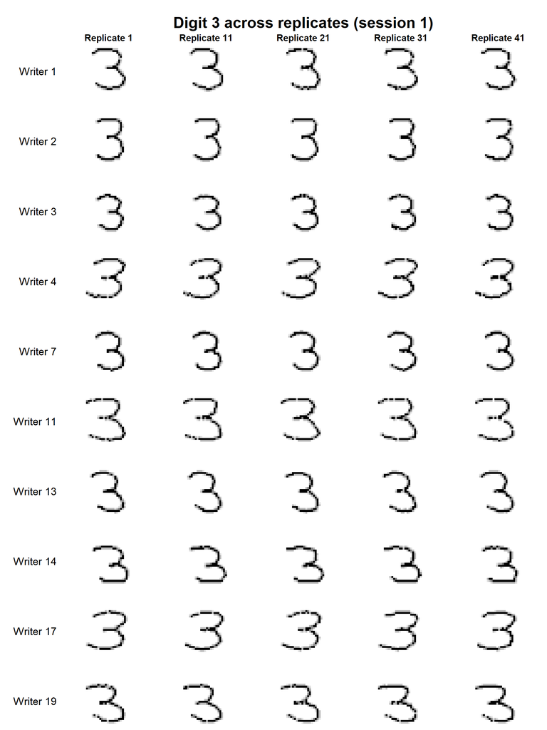

(c) Digit 3

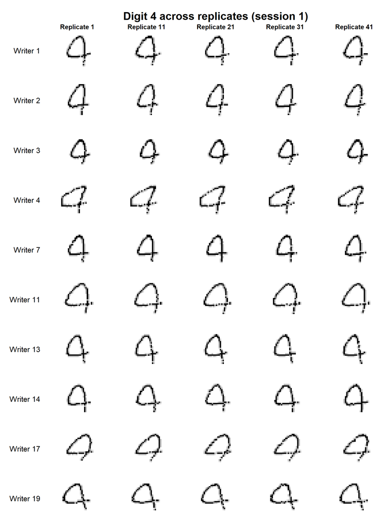

(d) Digit 4

Figure 17: Digits 0, 2, 3 and 4 for the same ten writers as in the sessions figure, with session 1 fixed and replicates 1, 11, 21, 31 and 41. Rows are writers and columns are replicates.

## 9 References

Agresti, A. (2019). *An introduction to categorical data analysis* (3rd ed.). Wiley.

Bischl, B., Binder, M., Lang, M., Pielok, T., Richter, J., Coors, S., Thomas, J., Ullmann, T., Becker, M., Boulesteix, A.-L., Deng, D., & Lindauer, M. (2023). Hyperparameter optimization: Foundations, algorithms, best practices, and open challenges. *WIREs Data Mining and Knowledge Discovery*, *13*(2), e1484. https://doi.org/10.1002/widm.1484

Chicco, D. (2021). Siamese neural networks: An overview. In H. Cartwright (Ed.), *Artificial neural networks* (Vol. 2190, pp. 73–94). Humana Press. https://doi.org/10.1007/978-1-0716-0826-5_3

Chollet, F., Kalinowski, T., & Allaire, J. J. (2022). *Deep learning with R* (2nd ed.). Manning Publications.

Efron, B., & Hastie, T. (2016). *Computer age statistical inference: Algorithms, evidence, and data science*. Cambridge University Press.

Goodfellow, I., Bengio, Y., & Courville, A. (2016). *Deep learning*. MIT Press.

Goulet-Pelletier, J.-C., & Cousineau, D. (2018). A review of effect sizes and their confidence intervals, part I: The Cohen’s d family. *The Quantitative Methods for Psychology*, *14*(4), 242–265.

Gu, J., Wang, Z., Kuen, J., Ma, L., Shahroudy, A., Shuai, B., Liu, T., Wang, X., Wang, G., Cai, J., & Chen, T. (2018). Recent advances in convolutional neural networks. *Pattern Recognition*, *77*, 354–377. https://doi.org/10.1016/j.patcog.2017.10.013

He, S., & Schomaker, L. (2019). Deep adaptive learning for writer identification based on single handwritten word images. *Pattern Recognition*, *88*, 64–74. https://doi.org/10.1016/j.patcog.2018.11.003

Kapoor, S., & Narayanan, A. (2023). Leakage and the reproducibility crisis in machine-learning-based science. *Patterns*, *4*(9), 100804. https://doi.org/10.1016/j.patter.2023.100804

Luque, A., Carrasco, A., Martín, A., & Heras, A. de las. (2019). The impact of class imbalance in classification performance metrics based on the binary confusion matrix. *Pattern Recognition*, *91*, 216–231.

Probst, P., Boulesteix, A.-L., & Bischl, B. (2019). Tunability: Importance of hyperparameters of machine learning algorithms. *Journal of Machine Learning Research*, *20*(53), 1–32.

Rehman, A., Naz, S., & Razzak, M. I. (2019). Writer identification using machine learning approaches: A comprehensive review. *Multimedia Tools and Applications*, *78*(8), 10889–10931.

Roberts, D. R., Bahn, V., Ciuti, S., Boyce, M. S., Elith, J., Guillera-Arroita, G., Hauenstein, S., Lahoz-Monfort, J. J., Schröder, B., Thuiller, W., Warton, D. I., Wintle, B. A., Hartig, F., & Dormann, C. F. (2017). Cross-validation strategies for data with temporal, spatial, hierarchical, or phylogenetic structure. *Ecography*, *40*(8), 913–929. https://doi.org/10.1111/ecog.02881

Saeb, S., Lonini, L., Jayaraman, A., Mohr, D. C., & Kording, K. P. (2017). The need to approximate the use-case in clinical machine learning. *GigaScience*, *6*(5), gix019. https://doi.org/10.1093/gigascience/gix019

Saravanan, V., Berman, G. J., & Sober, S. J. (2020). Application of the hierarchical bootstrap to multi-level data in neuroscience. *Neurons, Behavior, Data Analysis, and Theory*, *3*(5), 1–25.